# assigment Session 7

- Show All Code
- Hide All Code
- View Source

Author

Jan Pamula

# Loading libraries

```r
library(ggplot2)
```

# First plot

creating x and y axis variables and data-frame:

```r
first_x <- c(2009, 2010, 2011, 2012, 2013, 2014, 2015, 2016, 2017, 2018, 2019, 2020, 2021, 2022, 2023, 2024, 2025, 2026, 2027)
first_y <- c(0.048, 0.047, 0.045, 0.044, 0.046, 0.044, 0.044, 0.045, 0.0463, 0.0475, 0.0488, 0.05, 0.053, 0.0565, 0.06, 0.0625, 0.065, 0.0675, 0.07)
first_data <- data.frame(
  year = first_x,
  spend = first_y
)
```

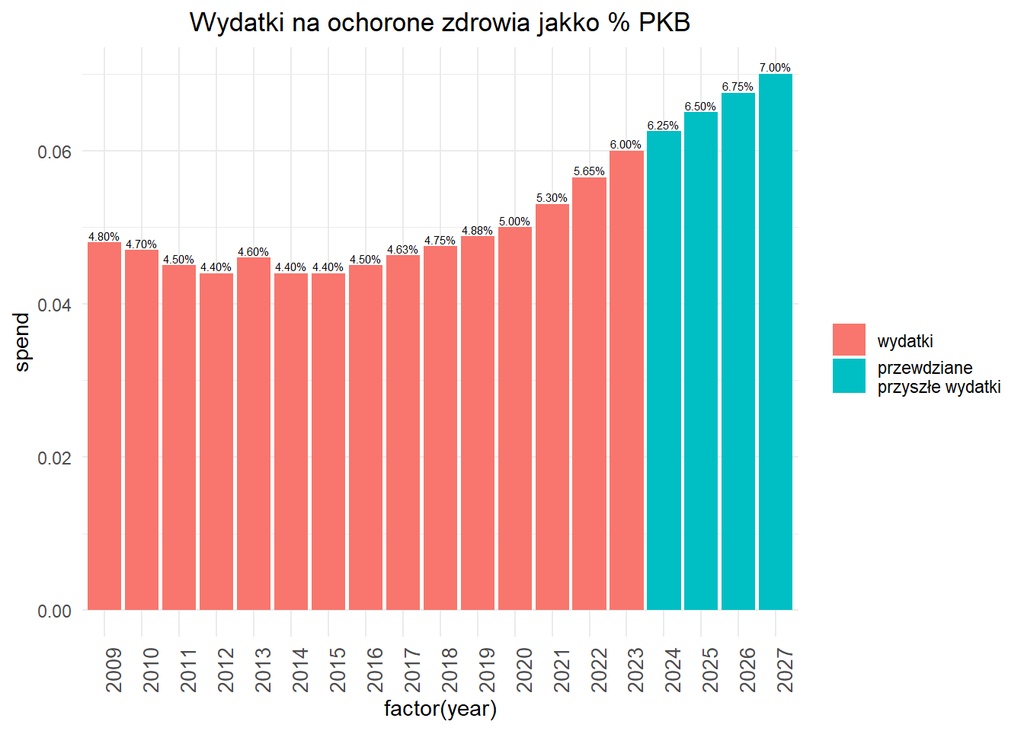

```r
p<-ggplot(data=first_data, aes(x=factor(year), y=spend)) +
  geom_bar(stat="identity",  aes(fill = year > 2023)) +
  geom_text(aes(label=scales::percent(spend)), vjust=-0.3, size=2) +
  scale_fill_discrete(name = "", labels=c('wydatki', "przewdziane \nprzyszłe wydatki")) +
  ggtitle("Wydatki na ochorone zdrowia jakko % PKB")+
  theme_minimal() +
  theme(plot.title = element_text(hjust = 0.5), axis.text.x = element_text(angle = 90, size = 10))
p
```

- `p<-` - assigning plot to variable (called “p”)
- `ggplot(data=first_data, aes(x=factor(year), y=spend))` - assign data to ggplot (x-axis = first_data.year, y-axis = first_data.spend)
- `geom_bar(stat="identity", aes(fill = year > 2023))` - creating bar chart where bars(years) > 2023 are colored for different color
- `geom_text(aes(label=scales::percent(spend)), vjust=-0.3, size=2)` - displaying every value on bars (in percentage)
- ggtitle(“Wydatki na ochorone zdrowia jakko % PKB”) - changing title
- `scale_fill_discrete(name = "", labels=c('wydatki', "przewdziane \nprzyszłe wydatki"))` - changing legend description
- `theme_minimal()` - using minimal theme
- `theme(plot.title = element_text(hjust = 0.5),` - centering title
- `axis.text.x = element_text(angle = 90, size = 10))` - rotating x-axis values

# Second plot

creating x and y axis variables and data-frame:

```r
second_x <- c("China", "US", "EEA", "India", "Russia", "Japan", "Other")
second_y <- c(0.294, 0.143, 0.098, 0.068, 0.049, 0.035, 0.315)
second_data <- data.frame(
  Country = second_x,
  Emission = second_y
)
```

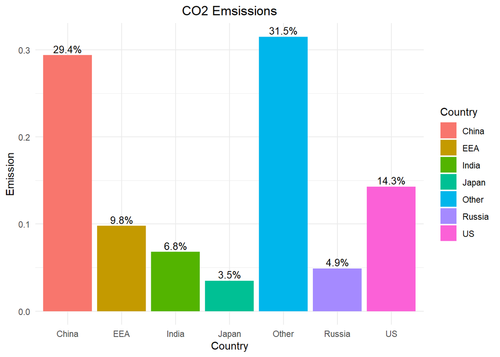

```r
q<-ggplot(data=second_data, aes(x=Country, y=Emission, fill = Country)) +
  geom_bar(stat="identity")+
  geom_text(aes(label=scales::percent(Emission)), vjust=-0.3, size=3.5) +
  ggtitle("CO2 Emsissions")+
  theme_minimal() +
  theme(plot.title = element_text(hjust = 0.5))
q
```